# DS 521 Final Project

Nick Kachanyuk

4/23/2021

```r
knitr::opts_chunk$set(echo = TRUE, message = FALSE, warning = FALSE, cache = TRUE)
```

```r
library(tidyverse)
library(tsibble)
library(fpp3)
library(seasonal)
library(feasts)
library(fable)
library(rmdformats)
library(patchwork)
```

## Loading the data

```r
SMHP <- read_csv("~/Data Science/Classes/DS 521/project/SMHP.csv")

ts_SMHP <- SMHP %>% mutate(Month = yearmonth(DATE), median_house_price = MELIPRMSA41420) %>% as_tsibble(index = Month) %>% select(-c(DATE, MELIPRMSA41420))
```

## Objective

The goals for this project are:

1. Explore the median house price history for real estate listings in Salem, OR.
2. Find models that are accurate as much as possible to predict further into the future 3 and 6 months ahead.

## Data Vizualizations

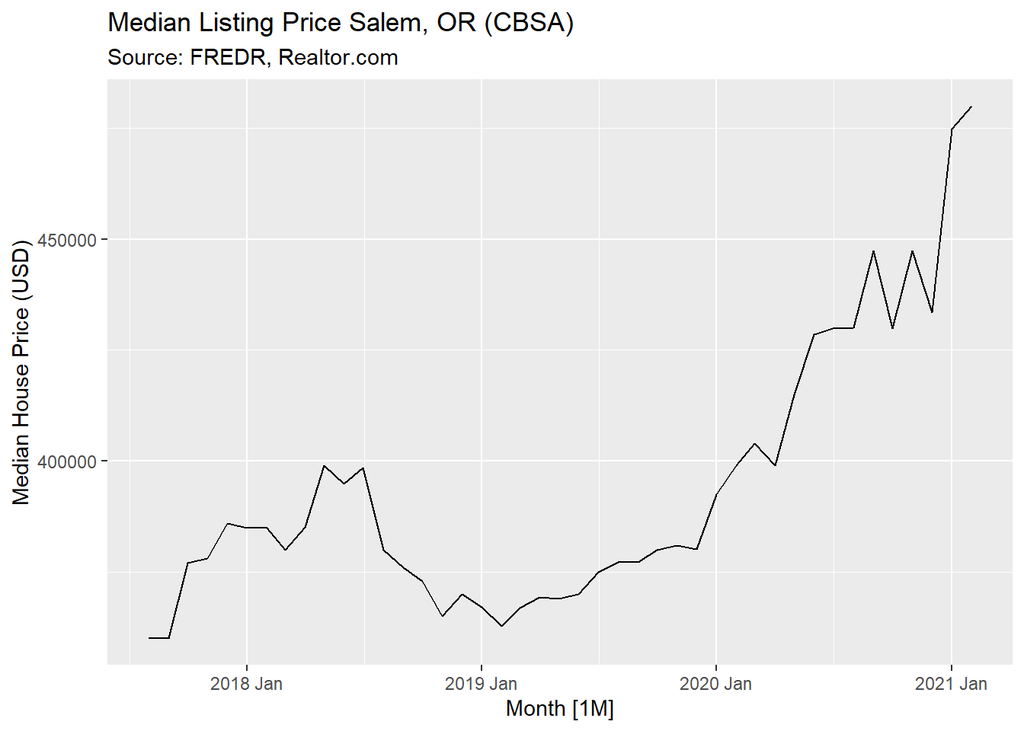

```r
plot1 <- autoplot(ts_SMHP, median_house_price) +
  labs(title = "Median Listing Price Salem, OR (CBSA)",
       subtitle = "Source: FREDR, Realtor.com",
       y = "Median House Price (USD)")

plot1
```

## Is a transformation necessary?

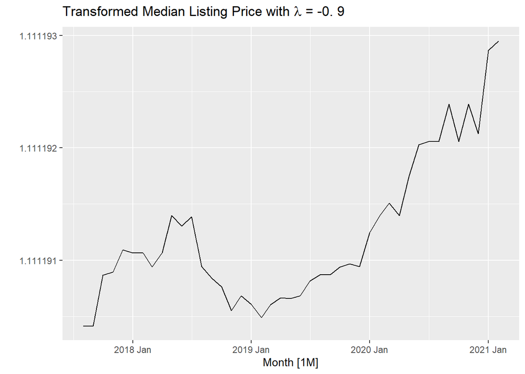

```r
lambda <- ts_SMHP %>%
  features(median_house_price, features = guerrero) %>%
  pull(lambda_guerrero)

plot2 <- ts_SMHP %>%
  autoplot(box_cox(median_house_price, lambda)) +
  labs(y = "",
       title = latex2exp::TeX(paste0(
         "Transformed Median Listing Price with $\\lambda$ = ",
         round(lambda,2))))

plot2
```

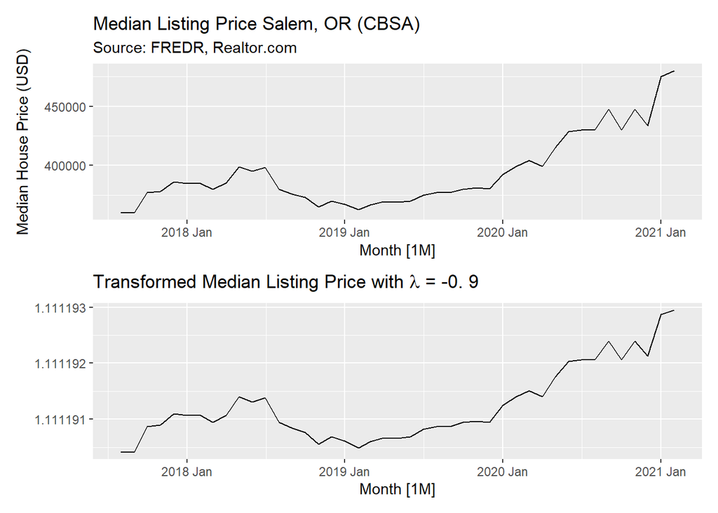

```r
plot1 / plot2
```

As we can see nothing really changes when the transformation with the recommended lambda is applied to our data. The lines of the transformed time series graphic seem to follow the same pattern as the original data but on a different and more confusing scale to follow. This indicates to me that the data can be fed into the models as is but I still need to examine whether or not the data is stationary.

## STL Decomposition

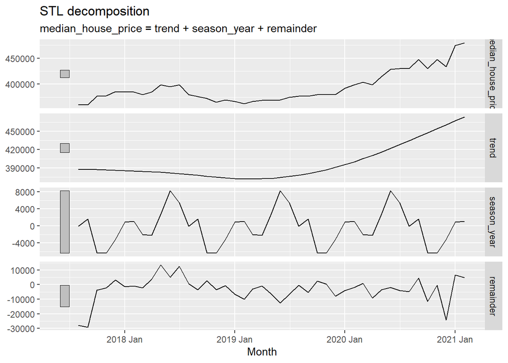

```r
ts_SMHP %>%
  model(
    STL(median_house_price ~ trend(window = 21) +
                   season(window = "periodic"),
    robust = TRUE)) %>%
  components() %>%
  autoplot()
```

## STL features

```r
ts_SMHP %>%
  features(median_house_price, feat_stl)
```

```
## # A tibble: 1 x 9
##   trend_strength seasonal_strength~ seasonal_peak_y~ seasonal_trough_~ spikiness
##            <dbl>              <dbl>            <dbl>             <dbl>     <dbl>
## 1          0.946              0.338                0                 5   1.81e12
## # ... with 4 more variables: linearity <dbl>, curvature <dbl>,
## #   stl_e_acf1 <dbl>, stl_e_acf10 <dbl>
```

It seems that there is a strong trend and possible some seasonality patterns in this data.

```r
ts_SMHP %>% features(median_house_price, unitroot_kpss)
```

```
## # A tibble: 1 x 2
##   kpss_stat kpss_pvalue
##       <dbl>       <dbl>
## 1     0.782        0.01
```

```r
ts_SMHP %>%
  features(median_house_price, unitroot_ndiffs)
```

```
## # A tibble: 1 x 1
##   ndiffs
##    <int>
## 1      1
```

One difference is required to make ts_SMHP data stationary. But what about seasonal differencing?

```r
ts_SMHP %>%
  features(median_house_price, unitroot_nsdiffs)
```

```
## # A tibble: 1 x 1
##   nsdiffs
##     <int>
## 1       0
```

No seasonal differencing required. This is also in agreement with the rule that states if Fs < 0.64, seasonal differences are not suggested (Hyndman and Athanasopoulos, FPP3, Ch.9.1). The Fs (seasonal strength) that we found out earlier was 0.34 for the ts_SMHP data.

## Train/test split of data

#### 3 step cross-validation

```r
ts_train_i18_s3 <- ts_SMHP %>%
  stretch_tsibble(.init = 18, .step = 3) %>%
  relocate(Month, median_house_price, .id)
```

#### 6 step cross validation

```r
ts_train_i12_s6 <- ts_SMHP %>%
  stretch_tsibble(.init = 12, .step = 6) %>%
  relocate(Month, median_house_price, .id)
```

## Models for 3 month forecasts

```r
fit <- ts_train_i18_s3 %>%
  model(
    simple_ETS = ETS(median_house_price ~ error("A") + trend("N") + season("N")),
    linear_trend_ETS = ETS(median_house_price ~ error("A") + trend("A") + season("N")),
    damped_linear_trend_ETS = ETS(median_house_price ~ error("A") + trend("Ad", phi=0.98) + season("N")),
    holt_winter_ETS = ETS(median_house_price ~ error("A") + trend("A") + season("A")),
    holt_winter_damped_ETS = ETS(median_house_price ~ error("A") + trend("Ad") + season("A")),
    automatic_ETS = ETS(median_house_price),
    automatic_ARIMA = ARIMA(median_house_price, stepwise = FALSE, approximation = FALSE),
    automatic_NNET = NNETAR(median_house_price)
    ) %>%
  mutate(
    Combo1 = (linear_trend_ETS + automatic_ARIMA)/2,
    Combo2 = (damped_linear_trend_ETS + automatic_ARIMA)/2,
    Combo3 = (linear_trend_ETS + automatic_ARIMA + automatic_NNET)/3,
    Combo4 = (damped_linear_trend_ETS + automatic_ARIMA + automatic_NNET)/3
  )
```

## Model evaluation

#### Accuracy metrics

```r
forecast_3step <- fit %>%
  filter(.id==8) %>%
  forecast(h=3)

forecast_3step %>%
  accuracy(ts_SMHP) %>% arrange(RMSE)
```

```
## # A tibble: 12 x 10
##    .model              .type     ME   RMSE    MAE   MPE  MAPE  MASE RMSSE   ACF1
##    <chr>               <chr>  <dbl>  <dbl>  <dbl> <dbl> <dbl> <dbl> <dbl>  <dbl>
##  1 linear_trend_ETS    Test  15604. 22304. 17501.  3.33  3.76 0.660 0.694 -0.447
##  2 damped_linear_tren~ Test  17980. 24368. 18300.  3.85  3.92 0.690 0.758 -0.420
##  3 Combo1              Test  18827. 25066. 18827.  4.03  4.03 0.710 0.780 -0.414
##  4 Combo3              Test  18612. 25319. 18645.  3.98  3.99 0.703 0.788 -0.394
##  5 automatic_NNET      Test  18145. 25879. 18793.  3.87  4.02 0.709 0.805 -0.358
##  6 Combo4              Test  19365. 25999. 19365.  4.15  4.15 0.731 0.809 -0.385
##  7 Combo2              Test  20015. 26142. 20015.  4.29  4.29 0.755 0.813 -0.401
##  8 automatic_ETS       Test  21627. 27632. 21627.  4.65  4.65 0.816 0.860 -0.384
##  9 simple_ETS          Test  21627. 27632. 21627.  4.65  4.65 0.816 0.860 -0.384
## 10 automatic_ARIMA     Test  22050  27964. 22050   4.74  4.74 0.832 0.870 -0.384
## 11 holt_winter_ETS     Test  23796. 28294. 23796.  5.15  5.15 0.898 0.880 -0.443
## 12 holt_winter_damped~ Test  24940. 29410. 24940.  5.40  5.40 0.941 0.915 -0.427
```

Looking at RMSE (other metrics follow the same pattern) it looks like the winning model is a linear trend ETS model.

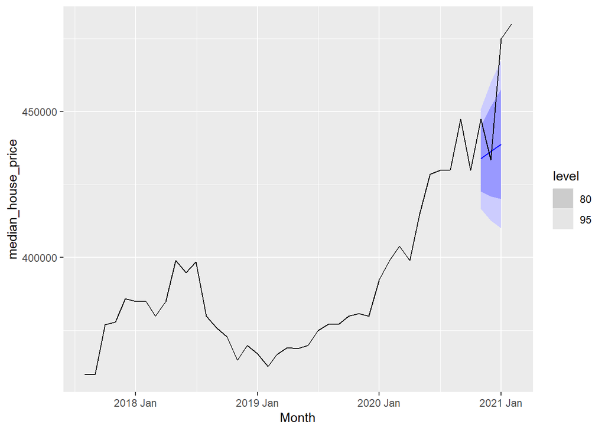

```r
forecast_3step %>%
  filter(.id==8 & .model=="linear_trend_ETS") %>%
  autoplot() +
  autolayer(ts_SMHP)
```

#### Residual diagnosis of the best model

```r
fit %>%
  select(linear_trend_ETS) %>%
  filter(.id==9) %>%
  report()
```

```
## Series: median_house_price
## Model: ETS(A,A,N)
##   Smoothing parameters:
##     alpha = 0.5857205
##     beta  = 0.1092335
##
##   Initial states:
##         l        b
##  372910.1 3400.434
##
##   sigma^2:  109596577
##
##      AIC     AICc      BIC
## 940.2959 941.9626 948.9843
```

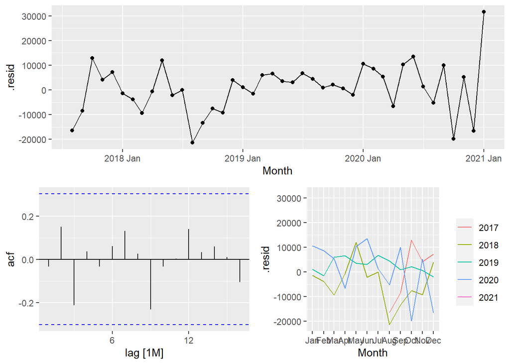

```r
fit %>% select(linear_trend_ETS) %>% filter(.id==9) %>% augment() %>% gg_tsdisplay(.resid)
```

```r
fit %>%
  select(linear_trend_ETS) %>%
  filter(.id==9) %>%
  augment() %>%
  features(.innov, ljung_box, lag = 6.8, dof = 2)
```

```
## # A tibble: 1 x 4
##     .id .model           lb_stat lb_pvalue
##   <int> <chr>              <dbl>     <dbl>
## 1     9 linear_trend_ETS    3.57     0.586
```

## Forecasting 3 months into the future

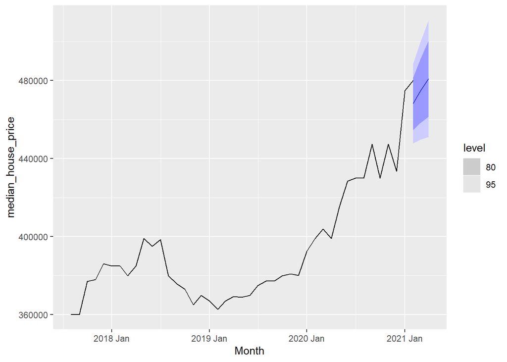

```r
fit %>%
  select(linear_trend_ETS) %>%
  filter(.id==9) %>%
  forecast(h=3) %>%
  autoplot() +
  autolayer(ts_SMHP)
```

Takeaway here is that the model is under-predicting the median house price. This is due to a large increase in the median house price from December 2020 to February 2021.

```r
fit %>%
  select(linear_trend_ETS) %>%
  filter(.id==9) %>%
  coef()
```

```
## # A tibble: 4 x 4
##     .id .model           term    estimate
##   <int> <chr>            <chr>      <dbl>
## 1     9 linear_trend_ETS alpha      0.586
## 2     9 linear_trend_ETS beta       0.109
## 3     9 linear_trend_ETS l     372910.
## 4     9 linear_trend_ETS b       3400.
```

## Models for 6 month forecasts

```r
fit2 <- ts_train_i12_s6 %>%
  model(
    simple_ETS = ETS(median_house_price ~ error("A") + trend("N") + season("N")),
    linear_trend_ETS = ETS(median_house_price ~ error("A") + trend("A") + season("N")),
    damped_linear_trend_ETS = ETS(median_house_price ~ error("A") + trend("Ad", phi=0.98) + season("N")),
    holt_winter_ETS = ETS(median_house_price ~ error("A") + trend("A") + season("A")),
    holt_winter_damped_ETS = ETS(median_house_price ~ error("A") + trend("Ad") + season("A")),
    automatic_ETS = ETS(median_house_price),
    automatic_ARIMA = ARIMA(median_house_price, stepwise = FALSE, approximation = FALSE),
    automatic_NNET = NNETAR(median_house_price)
    ) %>%
  mutate(
    Combo1 = (linear_trend_ETS + automatic_ARIMA)/2,
    Combo2 = (damped_linear_trend_ETS + automatic_ARIMA)/2,
    Combo3 = (linear_trend_ETS + automatic_ARIMA + automatic_NNET)/3,
    Combo4 = (damped_linear_trend_ETS + automatic_ARIMA + automatic_NNET)/3
  )
```

## Model evaluation

#### Accuracy metrics

```r
forecast_6step <- fit2 %>%
  filter(.id==5) %>%
  forecast(h=6)

forecast_6step %>%
  accuracy(ts_SMHP) %>% arrange(RMSE)
```

```
## # A tibble: 12 x 10
##    .model              .type     ME   RMSE    MAE   MPE  MAPE  MASE RMSSE   ACF1
##    <chr>               <chr>  <dbl>  <dbl>  <dbl> <dbl> <dbl> <dbl> <dbl>  <dbl>
##  1 linear_trend_ETS    Test   1488. 12952. 10957. 0.243  2.44 0.485 0.478 -0.555
##  2 damped_linear_tren~ Test   1295. 12994. 10980. 0.199  2.44 0.486 0.479 -0.550
##  3 Combo2              Test  10106. 17805. 12195. 2.17   2.65 0.540 0.657 -0.423
##  4 Combo1              Test  10202. 17827. 12184. 2.19   2.65 0.539 0.657 -0.426
##  5 simple_ETS          Test  13922. 21002. 13937. 3.02   3.02 0.617 0.774 -0.343
##  6 automatic_ETS       Test  13922. 21002. 13937. 3.02   3.02 0.617 0.774 -0.343
##  7 Combo4              Test  14285. 21864. 14415. 3.09   3.12 0.638 0.806 -0.308
##  8 Combo3              Test  14365. 21893. 14449. 3.11   3.13 0.639 0.807 -0.311
##  9 automatic_ARIMA     Test  18917. 25591. 18917. 4.13   4.13 0.837 0.944 -0.244
## 10 automatic_NNET      Test  22640. 30897. 22640. 4.95   4.95 1.00  1.14  -0.118
## 11 holt_winter_damped~ Test  34964. 37731. 34964. 7.78   7.78 1.55  1.39  -0.359
## 12 holt_winter_ETS     Test  35626. 38347. 35626. 7.93   7.93 1.58  1.41  -0.414
```

Again the linear trend ETS model does great here when compared against other models on accuracy metrics.

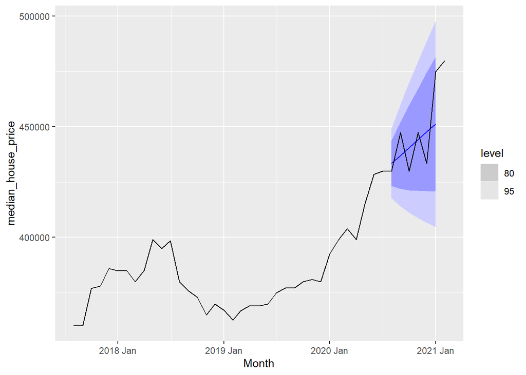

```r
forecast_6step %>%
  filter(.id == 5 & .model=="linear_trend_ETS") %>%
  autoplot() +
  autolayer(ts_SMHP)
```

#### Residual diagnosis of the best model

```r
fit2 %>%
  select(linear_trend_ETS) %>%
  filter(.id==6) %>%
  report()
```

```
## Series: median_house_price
## Model: ETS(A,A,N)
##   Smoothing parameters:
##     alpha = 0.5857205
##     beta  = 0.1092335
##
##   Initial states:
##         l        b
##  372910.1 3400.434
##
##   sigma^2:  109596577
##
##      AIC     AICc      BIC
## 940.2959 941.9626 948.9843
```

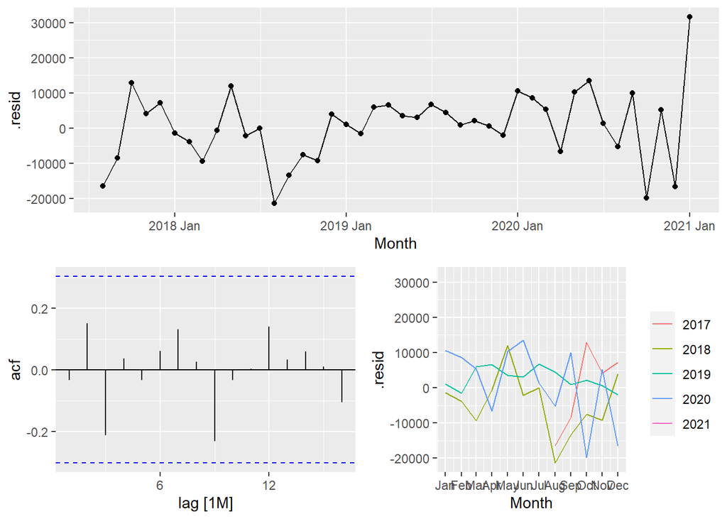

```r
fit2 %>% select(linear_trend_ETS) %>% filter(.id==6) %>% augment() %>% gg_tsdisplay(.resid)
```

```r
fit2 %>%
  select(linear_trend_ETS) %>%
  filter(.id==6) %>%
  augment() %>%
  features(.innov, ljung_box, lag = 6.8, dof = 2)
```

```
## # A tibble: 1 x 4
##     .id .model           lb_stat lb_pvalue
##   <int> <chr>              <dbl>     <dbl>
## 1     6 linear_trend_ETS    3.57     0.586
```

## Forecasting 6 months into the future

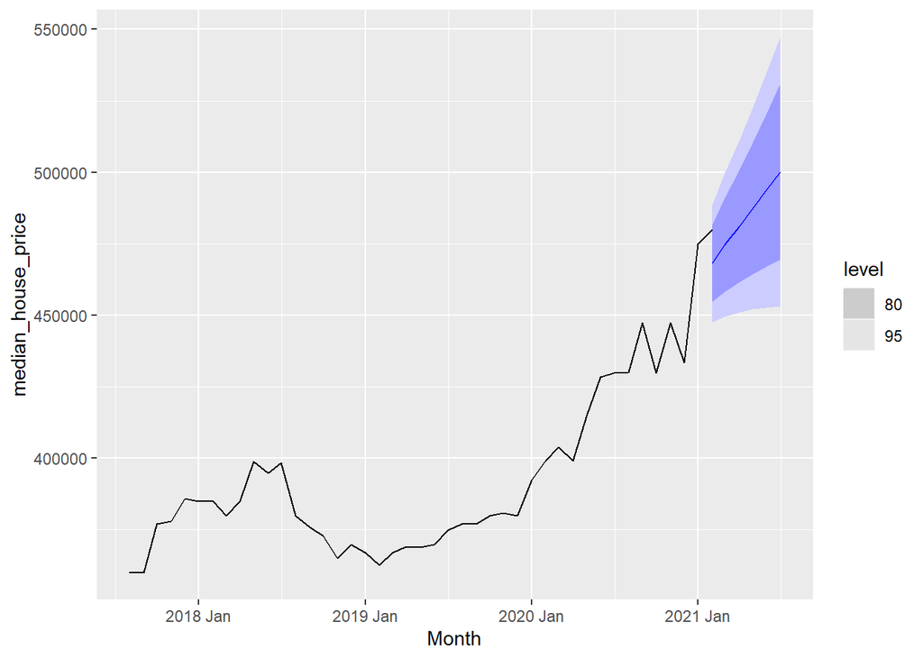

```r
fit2 %>%
  select(linear_trend_ETS) %>%
  forecast(h=6) %>%
  filter(.id==6) %>%
  autoplot()+
  autolayer(ts_SMHP)
```

```r
fit2 %>%
  select(linear_trend_ETS) %>%
  filter(.id==6) %>%
  coef()
```

```
## # A tibble: 4 x 4
##     .id .model           term    estimate
##   <int> <chr>            <chr>      <dbl>
## 1     6 linear_trend_ETS alpha      0.586
## 2     6 linear_trend_ETS beta       0.109
## 3     6 linear_trend_ETS l     372910.
## 4     6 linear_trend_ETS b       3400.
```

Same takeaway here is that the model is under-predicting the median house price. This is due to a large increase in the median house price from December 2020 to February 2021.

## Further considerations on model improvement and conclusions

The big picture seems to be that real estate prices are growing during the COVID-19 pandemic. Possible explanations for this behavior are economic indicators (employment, manufacturing, prices of goods), interest rates (lower interest rates = more demand for houses = increase in real estate prices), and government policies/subsidies that promote real estate purchases. Based on anecdotal experience from friends that work in the real estate industry, homes were in demand in 2020 due to low interest rates offered to people who qualify.

Possible improvements for modeling real estate median price can be the inclusion of additional predictors such as the change in interest rate, employment rate, and/or an indicator variable that captures whether or not a government policy has introduced a driver for demand in real estate. For example, in 2009 the government introduced a first-time homebuyer’s tax credit which according to National Association of Realtors led to 900,000 homebuyers to buy homes (https://www.investopedia.com/articles/mortages-real-estate/11/factors-affecting-real-estate-market.asp).

## Why are the factors mentioned above are of particular interest?

```r
SMHP_update <- read_csv("~/Data Science/Classes/DS 521/project/MELIPRMSA41420.csv")

ts_SMHP_update <- SMHP_update %>% mutate(Month = yearmonth(DATE), median_house_price = MELIPRMSA41420) %>% as_tsibble(index = Month) %>% select(-c(DATE, MELIPRMSA41420))
```

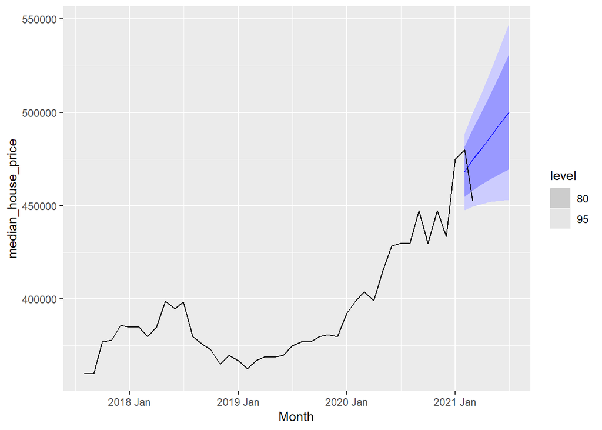

```r
fit2 %>%
  select(linear_trend_ETS) %>%
  forecast(h=6) %>%
  filter(.id==6) %>%
  autoplot()+
  autolayer(ts_SMHP_update)
```

As we can see from February to March 2021, real estate prices decreased rapidly. The model that was trained on data up to January 2021 over-predicts the median house price for this period.